# Data exploration: Rubenstein et al. 2023

# Summary

Read in the various .csv files to see what they contain and how they relate to one another

# Data sources

- Rubenstein et al. (2023). Climate change and the global redistribution of biodiversity: Substantial variation in empirical support for expected range shifts. Environmental Evidence, 12(1), 7. https://doi.org/10.1186/s13750-023-00296-0
- CoRE (Contractions or Range Expansions) Database: Global Database of Species Range Shifts from 1802-2019: Data downloaded from https://www.sciencebase.gov/catalog/item/64147d6fd34eb496d1ceb497

# Methods

```r
library(tidyverse)
library(here)
library(DBI)

library(sf)
```

## Set up data folders

See README.md for details on extraction into proper destination directories.

## Read in .csvs individually

Use `janitor::clean_names()` to standardize variable names to `snake_case`.

### Climate variables

```r
climate_df <- read_csv(here('_raw_data/db_range_shifts', 'Climate.Variables.csv')) %>%
  janitor::clean_names()
DT::datatable(climate_df)
```

|  | reference_number | variable_description |
| --- | --- | --- |
| 1 | A1 | Annual mean temperature |
| 2 | A2 | Annual mean diurnal range |
| 3 | A3 | Max temperature of warmest month (annual max) |
| 4 | A4 | Min temperature of coldest month (annual min) |
| 5 | A5 | Mean temperature of warmest month |
| 6 | A6 | Mean temperature of coldest month |
| 7 | A7 | Mean temperature of the warmest quarter (summer) |
| 8 | A8 | Mean temperature of the coldest quarter (winter) |
| 9 | A9 | Maximum temperature of warmest quarter (summer) |
| 10 | A10 | Minimum temperature of coldest quarter (winter) |

[output cut: 96 more lines]

### Paper details

These associate a `paperid` with variables about each paper: `author`, `title`, `year`, `journal`, `doi`. The dataframe is 315 observations across the six variables.

```r
paperid_df <- read_csv(here('_raw_data/db_range_shifts', 'PaperID.csv')) %>%
  janitor::clean_names()
head(paperid_df)
```

```
# A tibble: 6 × 6
  paperid author            title                             year journal doi
    <dbl> <chr>             <chr>                            <dbl> <chr>   <chr>
1       1 Currie et al      Climate change is not a major d…  2017 Global… 10.1…
2       2 Kelly and Goulden Rapid shifts in plant distribut…  2008 PNAS    10.1…
3       5 Morelli et al     Anthropogenic refugia ameliorat…  2012 Procee… 10.1…
4       6 Sultaire et al    Climate change surpasses land-u…  2016 Procee… 10.1…
5       7 Perry et al       Climate change and distribution…  2005 Science 10.1…
6       8 Lenoir et al      A significant upward shift in p…  2008 Science 10.1…
```

### Range shift details

This dataframe has a `paperid` column that corresponds to the `paperid` column in the paper details dataframe.

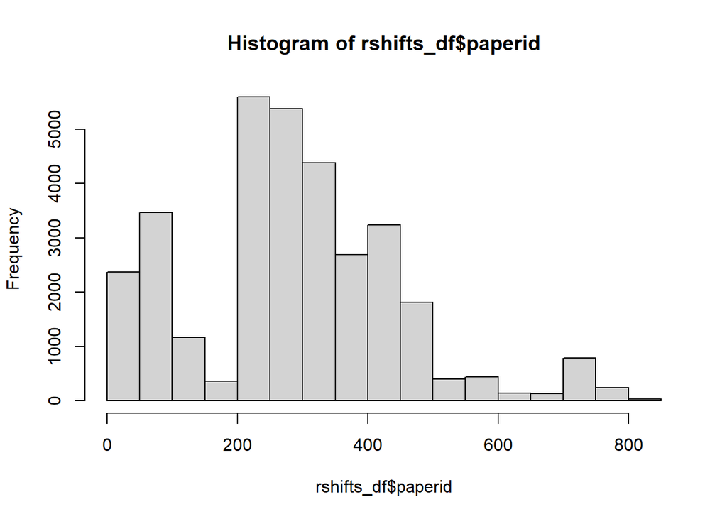

```r
rshifts_df <- read_csv(here('_raw_data/db_range_shifts', 'Range.Shifts.csv')) %>%
  janitor::clean_names()
# names(rshifts_df)
# x <- inner_join(rshifts_df, paperid_df, by = 'paperid')
# nrow(x) == nrow(rshifts_df)
### TRUE - all rshifts_df rows are accounted for
hist(rshifts_df$paperid)
```

```r
rshifts_df$temp %>% table()
```

```
.
                                                   A1
                                                15616
                                         A1, A10, A13
                                                   27
                                              A1, A11
                                                   28
                                    A1, A13, A12, A17
                                                  246
                                              A1, A17
                                                   12
                                              A1, A18
                                                   28
                                         A1, A18, A23
                                                  452
                                         A1, A20, A18
                                                  158
                                              A1, A23
                                                    1
                                         A1, A23, A25
                                                    2
                A1, A23, A25, A41, A42, A43, A44, A45
                                                    8
                                               A1, A3
                                                   34
                                           A1, A3, A4
                                                  144
                                               A1, A4
                                                    1
                                          A1, A4, A23
                                                  291
                                           A1, A5, A6
                                                    4
                       A1, A5, A7, A8, A18, A20, A23,
                                                   13
                                            A1, A5,A6
                                                    1
                                               A1, A7
                                                  123
                                           A1, A7, A8
```

[output cut: 168 more lines]

```
                                                    5
                                                   B6
                                                   29
                                               B6, B7
                                                    3
                                           B6, B8, B9
                                                   53
                                                   B7
                                                   21
                                                   B8
                                                   44
                                                   B9
                                                    9
                                               B9, B1
                                                  975
```

The `temp` column seems to contain codes related to `climate_df$reference_number` for both `A` and `B`, with multiple values in some rows separated by commas (e.g., `B9, B1`). Similar for the `precip` column for codes `C`. These are then associated with notes about Additional details on species name/taxonomic information, hemisphere, CASC.

### Species per paper

Most papers contain information on multiple species.

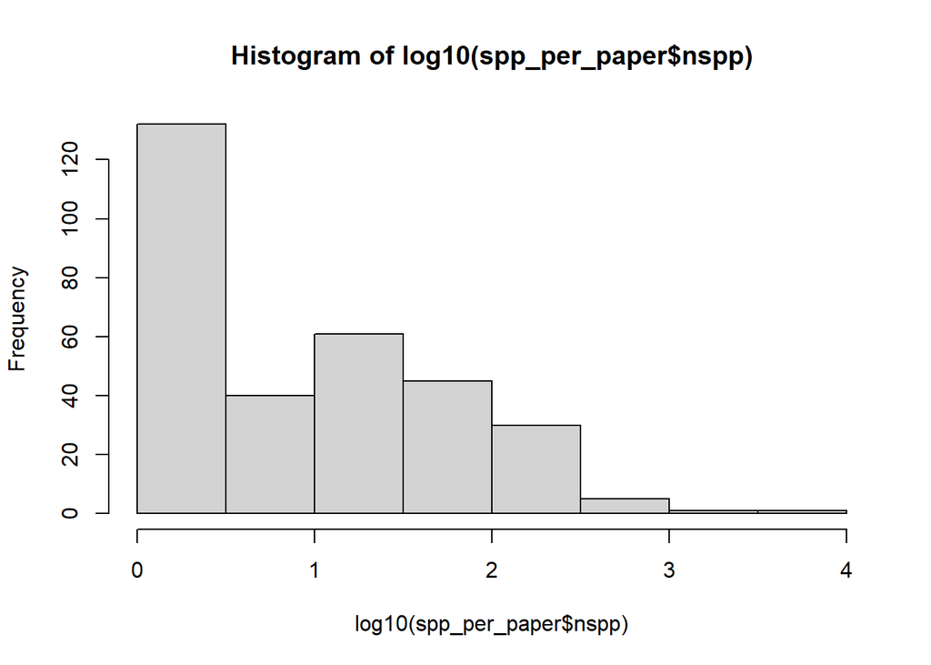

```r
spp_per_paper <- rshifts_df %>%
  group_by(paperid) %>%
  summarize(nspp = n_distinct(species))

hist(log10(spp_per_paper$nspp))
```

### Distinct species included

Separate out species taxonomic info from the climate and shift info using `species` as key. Note, common name `cname` is highly variable and not 1:1 match to `species` in either direction, so leave intact with the climate info.

```r
distinct_spp <- rshifts_df %>%
  select(sciname, tax,
         kingdom, phylum, class, order, family, genus, species, k2, t2) %>%
  distinct() %>%
  ### one spp name with two taxa - it is arachnid ("other"), NOT insect
  filter(!(tax == 'insect' & species == 'Ixodes ricinus'))

# spp_comname <- rshifts_df %>%
#   select(species, cname) %>%
#   mutate(cname = str_to_sentence(cname)) %>%
#   filter(!is.na(cname) & cname != 'N/a') %>%
#   distinct()
# x <- spp_comname %>% group_by(species) %>% filter(n() > 1)

rshifts_bare <- rshifts_df %>%
  select(-tax, -kingdom, -phylum, -class, -order, -family, -genus, -species, -k2, -t2)

# rshifts_df$sciname %>% n_distinct()
```

Seems there are 13098 distinct `species` but there are inconsistencies in common name (typos, punctuation, capitalization) and some subspecies/subpops. Can taxonomic info be pulled out into a separate relational table to reduce redundancy?

## Put tables in a SQL database?

The range shifts data still contains a ton of information in all those columns; but if there is a lot of redundancy it might make sense to put into separate related tables.

```r
db_file <- here('_raw_data/db_range_shifts.sqlite')

if(file.exists(db_file)) unlink(db_file)

mydb <- dbConnect(RSQLite::SQLite(), db_file)
dbWriteTable(mydb, 'paper_id', paperid_df)
dbWriteTable(mydb, 'climate_variables', climate_df)
dbWriteTable(mydb, 'tax_names', distinct_spp)
dbWriteTable(mydb, 'range_shifts', rshifts_bare)

dbDisconnect(mydb)
```

- Pre-SQL: 38 MB across three csv
- Post-SQL: 34.8 MB in a single database with four tables.

To retrieve:

```r
mydb <- dbConnect(RSQLite::SQLite(), db_file)
dbListTables(mydb)
```

```
[1] "climate_variables" "paper_id"          "range_shifts"
[4] "tax_names"
```

```r
rshifts_bare2 <- dbGetQuery(mydb, 'SELECT * from range_shifts')
dbDisconnect(mydb)
```

## Read in shapefiles

```r
studyarea_sf <- read_sf(here('_raw_data/studyarea_shapefiles',
                             'studyarea.shapefiles.shp')) %>%
  janitor::clean_names()

names(studyarea_sf)
```

```
[1] "name"     "paperid"  "avlblty"  "quality"  "access"   "sptlnts"  "geometry"
```

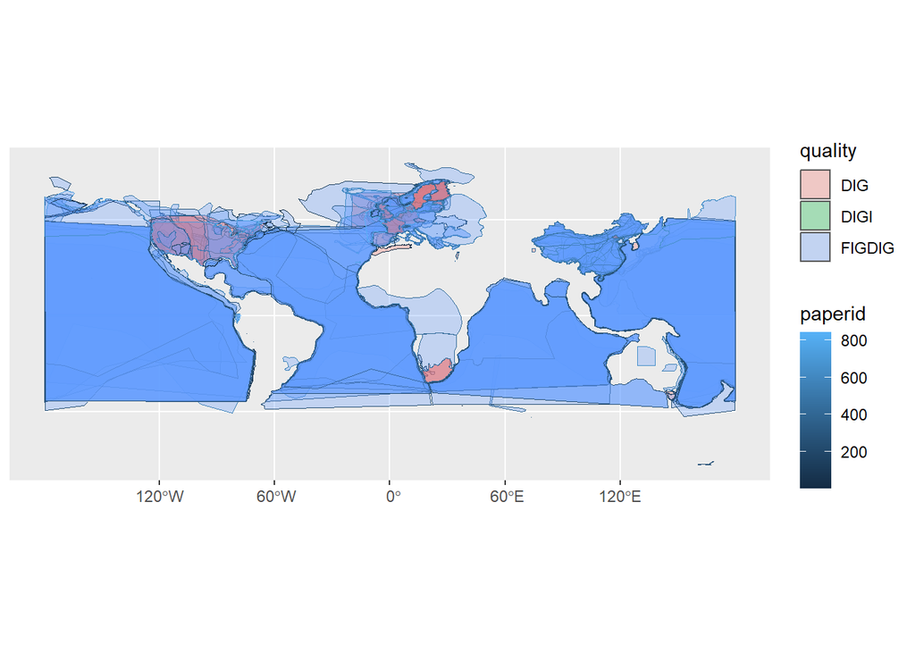

```r
ggplot(data = studyarea_sf) +
  geom_sf(aes(color = paperid, fill = quality), alpha = .3)
```